# GDP per capita and life expectancy in 2020

This report uses Gapminder-style country panels for **GDP per capita** (`gdp_pcap.csv`) and **life expectancy at birth** (`lex.csv`), restricted to **2020**.

## Data structure

Each file is in **wide** form: `geo` (3-letter code), `name`, and one column per year. The tables below show the first five countries and a few year columns.

**Sample: GDP per capita** (first rows, selected years)

| geo | name | 1800 | 1950 | 2000 | 2020 |
| --- | --- | --- | --- | --- | --- |
| afg | Afghanistan | 560.8882 | 1728.976 | 1426.509 | 2769.686 |
| ago | Angola | 435.2326 | 2490.898 | 5352.491 | 7556.968 |
| alb | Albania | 547.5337 | 2169.303 | 6558.423 | 14662.796 |
| and | Andorra | 1598.5313 | 9702.541 | 52814.695 | 55488.490 |
| are | UAE | 1332.7771 | 1839.030 | 88047.227 | 65784.677 |

**Sample: Life expectancy** (first rows, selected years)

| geo | name | 1800 | 1950 | 2000 | 2020 |
| --- | --- | --- | --- | --- | --- |
| afg | Afghanistan | 28.21 | 49.1 | 61.2 | 64.6 |
| ago | Angola | 26.98 | 40.8 | 54.0 | 62.8 |
| alb | Albania | 35.40 | 55.1 | 75.1 | 77.4 |
| and | Andorra | NA | 70.0 | 80.8 | 82.7 |
| are | UAE | 30.70 | 45.1 | 72.7 | 79.5 |

## 2020 subset

After dropping rows with missing 2020 values for either indicator, the analysis uses 193 countries with both GDP per capita and life expectancy in 2020.

## World maps (2020)

Country values are matched to map polygons via `maps::iso3166` (ISO alpha-3 to map region name) and `ggplot2::map_data("world")`. Unmatched or missing countries appear in light grey.

[figure not shown]

[figure not shown]

## Relationship in 2020

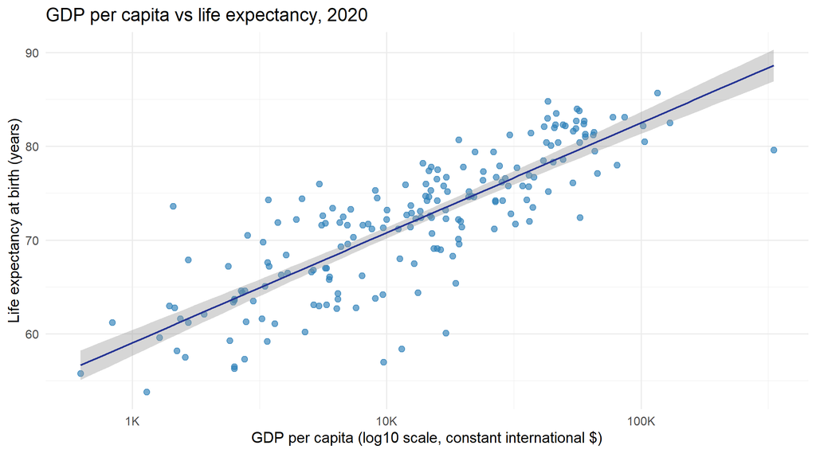

Pearson correlation (on raw GDP values): **0.575**.

**Summary of paired 2020 observations**

| n | median_gdp | median_lex | min_gdp | max_gdp | min_lex | max_lex |
| --- | --- | --- | --- | --- | --- | --- |
| 193 | 14397.2 | 72.6 | 625.7 | 332201.8 | 53.8 | 85.7 |

## Interpretation

In 2020, **higher GDP per capita is associated with higher life expectancy** across countries: the cloud of points slopes upward, especially on a log scale for income, and the fitted line on the log scale is clearly positive. Richer countries cluster toward the top-right; many low-income countries have lower life expectancy, though there is **meaningful dispersion** (public health, inequality, institutions, and recent shocks all move countries off a simple income–longevity line).

## Reflection

Interacting with cursor was easy. I entered the prompts I needed to create the report with the dataset. The result is amazing and so much time was saved using this tool.